# 05a Model Preparation

Author names redacted

2020-12-06

# 1 Load

## 1.1 New data

Load the newly created data of Russia interventions post-1994.

```r
df <- readRDS(paste0(here::here(), '/data/grayzone_aggregate_new.rds'))
```

## 1.2 European states

Load a blank dataset of European countries from 1994-2018. We use the list of COW states. The time series is constant for all countries except for Montenegro which exists from 2006 onwards and Kosovo which exists from 2008 onward.

```r
full <- read.csv(paste0(here::here(), "/inst/extdata/system2016.csv")) %>%
  dplyr::select(-version)

# Subset to Europe and code Georgia, Kosovo, Turkey, Yugoslavia, and Czech Republic as Europe
full$continent <- countrycode::countrycode(full$ccode, 'cown', 'continent')
full$continent[full$stateabb == "GRG"] <- "Europe"
full$continent[full$stateabb == "KOS"] <- "Europe"
full$continent[full$stateabb == "TUR"] <- "Europe"
full$continent[full$stateabb == "YUG"] <- "Europe"
full$continent[full$stateabb == "CZE" | full$stateabb == "CZR"] <- "Europe"

full <- full %>%
  dplyr::filter(continent == "Europe" | stateabb == "CAN" | stateabb == "SAU" | stateabb == "SYR" | stateabb == "USA") %>% # Include non-European states in the original data
  dplyr::filter(year > 1993) %>%
  dplyr::select(-continent)

# Add 2017 and 2018 for all states
countries <- as.character(sort(unique(full$ccode)))
newyr <- data.frame(expand.grid(ccode = c(countries),
                 year = 2017:2018))
newyr$ccode <- as.numeric(as.character(newyr$ccode))
newyr$stateabb <- countrycode::countrycode(newyr$ccode, "cown", "cowc")

full <- rbind(full, newyr)

full <- full %>%
  dplyr::rename(country_code_cow = ccode)

DT::datatable(plyr::count(full, "stateabb"))
```

|  | stateabb | freq |
| --- | --- | --- |
| 1 | ALB | 25 |
| 2 | AND | 25 |
| 3 | AUS | 25 |
| 4 | BEL | 25 |
| 5 | BLR | 25 |
| 6 | BOS | 25 |
| 7 | BUL | 25 |
| 8 | CAN | 25 |
| 9 | CRO | 25 |
| 10 | CZR | 25 |

[output cut: 40 more lines]

```r
DT::datatable(plyr::count(full, "year"))
```

|  | year | freq |
| --- | --- | --- |
| 1 | 1994 | 48 |
| 2 | 1995 | 48 |
| 3 | 1996 | 48 |
| 4 | 1997 | 48 |
| 5 | 1998 | 48 |
| 6 | 1999 | 48 |
| 7 | 2000 | 48 |
| 8 | 2001 | 48 |
| 9 | 2002 | 48 |
| 10 | 2003 | 48 |

[output cut: 15 more lines]

## 1.3 Subset of relevant European states

We want to include all European countries that a) have conflict history with Russia between 1945-1993, b) were former Soviet states, c) are contiguous with Russia. We add a fourth criteria of states that are targets of Russian attacks at any point during our time period, which is unique from the other 3 for Austria, Malta, Spain, and Germany. We include separate measures for inclusion in both criteria for robustness

```r
# Conflict history
## MID
mid <- haven::read_dta(paste0(here::here(),"/inst/extdata/MID/MIDB 4.3.dta"))

# Subset to columns of interest
mid <- mid %>%
  dplyr::select(dispnum3, ccode, styear) %>%
  dplyr::filter(styear > 1945 & styear < 1994) %>%
  dplyr::select(-styear) %>%
  dplyr::group_by(dispnum3) %>%
  dplyr::filter(any(ccode == 365)) %>%
  dplyr::ungroup() %>%
  dplyr::filter(!ccode == 365) %>%
  dplyr::select(-dispnum3) %>%
  dplyr::distinct() %>%
  dplyr::mutate(disphist = 1) %>%
  dplyr::rename(country_code_cow = ccode)

## ICB
icb <- read.csv(file = paste0(here::here(), '/inst/extdata/icb2v12.csv'))

icb <- icb %>%
  dplyr::select(crisno, cracid, yrtrig) %>%
  dplyr::filter(yrtrig > 1945 & yrtrig < 1994) %>%
  dplyr::select(-yrtrig) %>%
  dplyr::group_by(crisno) %>%
  dplyr::filter(any(cracid == 365)) %>%
  dplyr::ungroup() %>%
  dplyr::filter(!cracid == 365) %>%
  dplyr::select(-crisno) %>%
  dplyr::distinct() %>%
  dplyr::rename(country_code_cow = cracid) %>%
  dplyr::mutate(disphist = 1)

## Merge the two
disphist <- dplyr::bind_rows(mid, icb) %>%
  dplyr::distinct()

# FSU
fsu <- read.csv(paste0(here::here(), "/data/membership.csv"))

fsu <- fsu %>%
  dplyr::select(state, fsu, wp) %>%
  dplyr::filter(fsu == 1 | wp == 1) %>%
  dplyr::mutate(fsu_wp = fsu == 1 | wp == 1)
fsu$fsu_wp[fsu$fsu_wp == "TRUE"] <- 1

fsu$country_code_cow <- countrycode::countrycode(fsu$state, "country.name", "cown")

fsu <- fsu %>%
  dplyr::select(country_code_cow, fsu_wp)

# Contiguous
contig <- haven::read_dta(paste0(here::here(),"/inst/extdata/DirectContiguity320/contdird.dta"))

contig <- contig %>%
  dplyr::filter(year > 1945 & year < 1994) %>%
  dplyr::filter(state1no == 365) %>%
  dplyr::mutate(contig = conttype < 4) %>%
  dplyr::select(state2no, year, contig) %>%
  dplyr::rename(country_code_cow = state2no) %>%
  dplyr::filter(contig == "TRUE")

contig$year <- as.integer(contig$year)

# In DCID, REI, or new intervention data
cyber <- df

cyber$country_code_cow <- countrycode::countrycode(cyber$target, "country.name", "cown")

cyber <- cyber %>%
  dplyr::mutate(interv = resp_convmil == 1 |
                  resp_convmil_gro == 1 |
                  resp_convmil_airsea == 1 |
                  resp_paramil == 1 |
                  resp_cyberdisrup == 1 |
                  resp_infoops == 1) %>%
  dplyr::select(country_code_cow, interv) %>%
  dplyr::distinct()
cyber$interv[cyber$interv == "TRUE"] <- 1

cyber$continent <- countrycode::countrycode(cyber$country_code_cow, 'cown', 'continent')
cyber$continent[cyber$country_code_cow == "372"] <- "Europe" # Georgia
cyber$continent[cyber$country_code_cow == "347"] <- "Europe" # Kosovo
cyber$continent[cyber$country_code_cow == "640"] <- "Europe" # Turkey
cyber$continent[cyber$country_code_cow == "345"] <- "Europe" # Yugoslavia
cyber$continent[cyber$country_code_cow == "315" | cyber$stateabb == "316"] <- "Europe" # Czech Republic

# Combine them all with the main data
full <- dplyr::left_join(full, disphist)
full <- dplyr::left_join(full, fsu)
full <- dplyr::left_join(full, contig)
full <- dplyr::left_join(full, cyber)

full <- full %>%
  dplyr::mutate(relevant_conserv = continent == "Europe" & (disphist == 1 | fsu_wp == 1 | contig == 1)) %>%
  dplyr::mutate(relevant_expansive = (disphist == 1 | fsu_wp == 1 | contig == 1 | interv == 1)) %>%
  dplyr::select(stateabb, country_code_cow, year, relevant_conserv, relevant_expansive)

full$relevant_conserv[full$relevant_conserv == "TRUE"] <- "1"
full$relevant_conserv[is.na(full$relevant_conserv)] <- "0"
full$relevant_conserv <- as.numeric(full$relevant_conserv)

full$relevant_expansive[full$relevant_expansive == "TRUE"] <- "1"
full$relevant_expansive[is.na(full$relevant_expansive)] <- "0"
full$relevant_expansive <- as.numeric(full$relevant_expansive)
```

# 2 Clean

```r
# Subset and replace NAs with 0s for intensity variables
df <- df %>% dplyr::select(target, year_start, dplyr::starts_with("resp_")) %>%
  dplyr::rename(year = year_start) %>%
  dplyr::mutate(target = dplyr::recode(target, US = "United States", UK = "United Kingdom")) %>%
  tidyr::replace_na(list(resp_convmil = 0, resp_convmil_gro = 0, resp_convmil_airsea = 0, resp_paramil = 0, resp_cyberdisrup = 0, resp_infoops = 0))
df$target <- stringr::str_trim(df$target)

# Give ordinal value to each level
df$resp_convmil_gro <- df$resp_convmil_gro * 5
df$resp_convmil_airsea <- df$resp_convmil_airsea * 4
df$resp_paramil <- df$resp_paramil * 3
df$resp_cyberdisrup <- df$resp_cyberdisrup * 2
df$resp_infoops <- df$resp_infoops * 1

# Keep highest value per year
for( i in 1:nrow(df)){
  df$intensity[i] <- max(df$resp_convmil_gro[i],
                         df$resp_convmil_airsea[i],
                         df$resp_paramil[i],
                         df$resp_cyberdisrup[i],
                         df$resp_infoops[i])
}

# Subset to the highest value for country-year
df <- df %>%
  dplyr::group_by(target, year) %>%
  dplyr::filter(intensity == max(intensity)) %>%
  dplyr::select(target, year, intensity) %>%
  dplyr::distinct()
```

Merge the cleaned gray zone data into the Europe country-year dataset. This drops the Chechnya 1999 observation since they are not a recognized European state in the COW dataset

```r
# Add cow codes to gray zone data for merging
df$country_code_cow <- countrycode::countrycode(df$target, "country.name", "cown")
df$country_code_cow <- as.numeric(df$country_code_cow)
df <- df %>%
  dplyr::ungroup() %>%
  dplyr::select(country_code_cow, year, intensity)

# Merge
df <- dplyr::full_join(full, df)

# Fix state names and abbrevations that were lost in the merging
df$stateabb <- countrycode::countrycode(df$country_code_cow, "cown", "cowc")
df$statename <- countrycode::countrycode(df$country_code_cow, "cown", "country.name")

# Set non-events as 0
df$intensity[is.na(df$intensity)] <- 0

# Set countries that don't meet our 3-prong criteria as 0. Here, that primarily means non-European targets of Russian attacks (US, Canada, Saudi Arabia, etc) as well as some European states like Malta, Spain, Germany, and Austria. Do the same for the expansive criteria
df$relevant_conserv[is.na(df$relevant_conserv)] <- 0
df$relevant_expansive[is.na(df$relevant_expansive)] <- 0

# Drop non-countries, which is just Chechnya
df <- df %>%
  dplyr::filter(!is.na(country_code_cow))

# Drop Russia since we are not counting attacks on self
df <- df %>%
  dplyr::filter(!country_code_cow == 365)
```

# 3 Rename vars

```r
df <- df %>%
  dplyr::rename(cname1 = statename, cabbrev1 = stateabb, ccode1 = country_code_cow) %>%
  dplyr::select(year, cname1, cabbrev1, ccode1, intensity, relevant_conserv, relevant_expansive)

df$ccode1 <- as.numeric(df$ccode1)
```

# 4 Add variables

We add a battery of variables for the RHS of the model. SideB is always Russia, so we can hard-code that variable.

```r
# COW codes
df$cname2 <- "Russia"
df$cabbrev2 <- "RUS"
df$ccode2 <- 365

# Re-order the vars to make things more aesthetically pleasing
df <- df %>%
  dplyr::select(year, cname1, cabbrev1, ccode1, cname2, cabbrev2, ccode2, relevant_conserv, relevant_expansive, intensity)
```

## 4.1 Distance

### 4.1.1 From US

This is an independent variable of interest, coding how far the target state is from the US as the geographic proxy for deterrence. We code capital to capital distance using the cshapes package.

```r
# Capital distance
df_dist <- read.table(paste0(here::here(), '/inst/extdata/capdist.csv'), header = TRUE, sep = ",")

df_dist <- df_dist %>%
  dplyr::filter(numb == 2) %>%
  dplyr::select(ida, numa, kmdist) %>%
  dplyr::rename(capdistkm_us = kmdist, ccode1 = numa, cabbrev1 = ida)

# Recode cabbrev1 for the UK and Romania, which are given 2 letter abbreviations
df_dist$cabbrev1[df_dist$ccode1 == 200] <- "UKG"
df_dist$cabbrev1[df_dist$ccode1 == 360] <- "ROM"

df <- dplyr::left_join(df, df_dist)

## Fix edge cases where distance measures don't exist yet
### Kosovo KOS 347. We calculate the great circle distance between Washington, DC and Pristina, Kosovo using distancecalculator.net. This is the same measure used in the cshapes package, which does not include Kosovo since it ends in 2008
df$capdistkm_us[df$cabbrev1 == "KOS"] <- 7770

### United States USA 2
df$capdistkm_us[df$cabbrev1 == "USA"] <- 0

# Minimum distance
df_dist <- read.table(paste0(here::here(), '/inst/extdata/distance.txt'), header = TRUE, sep = " ")

df_dist <- df_dist %>%
  dplyr::filter(ccode2 == 2) %>%
  dplyr::select(ccode1, mindist, year) %>%
  round(df_dist$mindist) %>%
  dplyr::rename(mindistkm_us = mindist)
df <- dplyr::left_join(df, df_dist)

## Fix edge cases. These values exist for other years, so we just paste them in for the years that are missing
### Montenegro MNG 341
df$mindistkm_us[df$cabbrev1 == "MNG"] <- 6451.2804

### Kosovo KOS 347
df$mindistkm_us[df$cabbrev1 == "KOS"] <- 6571.540

### Saudi Arabia SAU 670
df$mindistkm_us[df$cabbrev1 == "SAU"] <- 8457.862
```

### 4.1.2 From Russia

We code distance from Russia to control for Russian resolve using the same data as above.

```r
# Capital distance
df_dist <- read.table(paste0(here::here(), '/inst/extdata/capdist.csv'), header = TRUE, sep = ",")

df_dist <- df_dist %>%
  dplyr::filter(numb == 365) %>%
  dplyr::select(ida, numa, kmdist) %>%
  dplyr::rename(capdistkm_rus = kmdist, ccode1 = numa, cabbrev1 = ida)

# Recode cabbrev1 for the UK and Romania, which are given 2 letter abbreviations
df_dist$cabbrev1[df_dist$ccode1 == 200] <- "UKG"
df_dist$cabbrev1[df_dist$ccode1 == 360] <- "ROM"

df <- dplyr::left_join(df, df_dist)

## Edge cases
### Kosovo
df$capdistkm_rus[df$cabbrev1 == "KOS"] <- 1873

## Russia
df$capdistkm_rus[df$cabbrev1 == "RUS"] <- 0

# Minimum distance
df_dist <- read.table(paste0(here::here(), '/inst/extdata/distance.txt'), header = TRUE, sep = " ")

df_dist <- df_dist %>%
  dplyr::filter(ccode2 == 365) %>%
  dplyr::select(ccode1, mindist, year) %>%
  round(df_dist$mindist) %>%
  dplyr::rename(mindistkm_rus = mindist)

df <- dplyr::left_join(df, df_dist)

## Fix edge cases. These values exist for other years, so we just paste them in for the years that are missing
### Kosovo KOS 347
df$mindistkm_rus[df$cabbrev1 == "KOS"] <- 1223.033956969140035653

### Montenegro
df$mindistkm_rus[df$cabbrev1 == "MNG"] <- 1211

### Saudi Arabia
df$mindistkm_rus[df$cabbrev1 == "SAU"] <- 1206.6503

# Round distance columns to the nearest kilometer
df$capdistkm_us <- round(df$capdistkm_us)
df$mindistkm_us <- round(df$mindistkm_us)

df$capdistkm_rus <- round(df$capdistkm_rus)
df$mindistkm_rus <- round(df$mindistkm_rus)
```

### 4.1.3 Recent years

For both countries and both measures, we do not have minimum distance data for 2017 and 2018. We impute the values from 2016 into each of those, with the assumption that land borders for European states have not changed since 2016

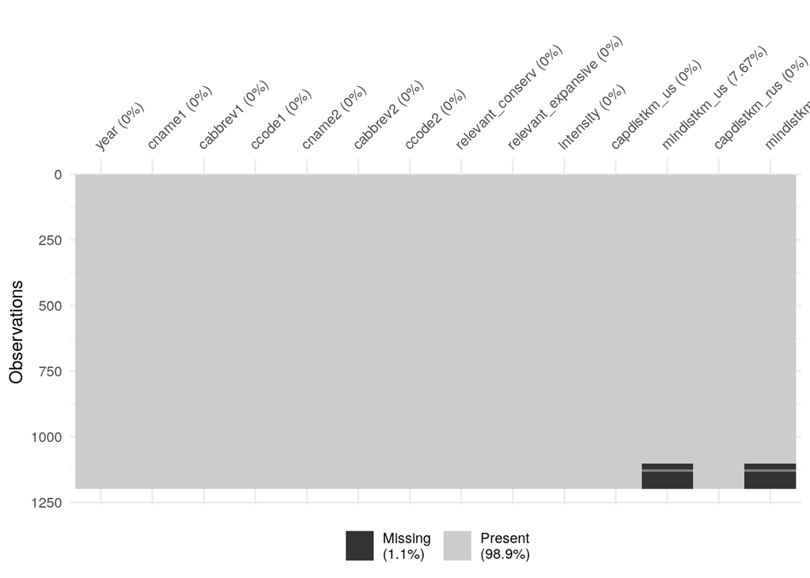

```r
naniar::vis_miss(df)
```

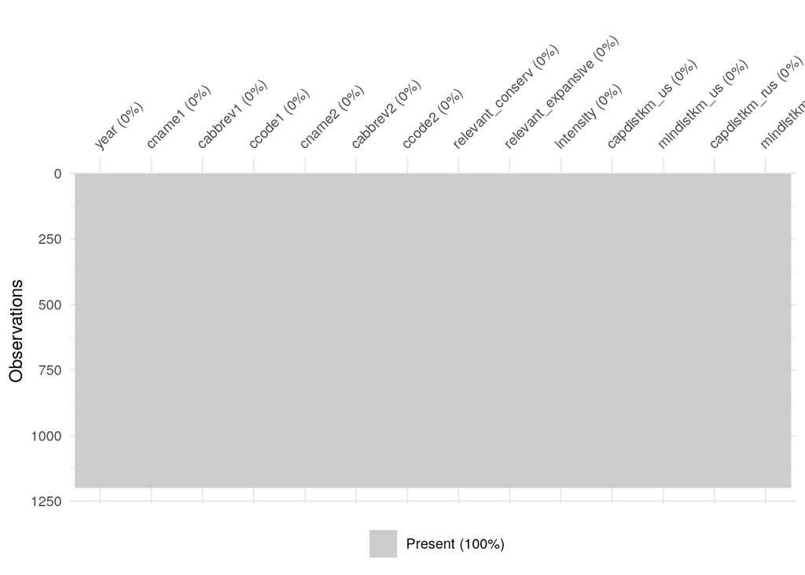

```r
# Create list of 2016 minimum distances
mindist <- df %>%
  dplyr::select(year, ccode1, mindistkm_us, mindistkm_rus) %>%
  dplyr::filter(year == 2016) %>%
  dplyr::select(-year) %>%
  dplyr::rename(mindistkm_us_impute = mindistkm_us, mindistkm_rus_impute = mindistkm_rus)

# Convert that into a df with year values
countries <- as.character(sort(unique(mindist$ccode1)))

newdist <- data.frame(expand.grid(ccode1 = c(countries),
                                  year = 2017:2018))
newdist$ccode1 <- as.numeric(as.character(newdist$ccode1))

newdist <- dplyr::left_join(newdist, mindist)

# Merge into original df
df <- dplyr::left_join(df, newdist)

# Replace NAs in original distance columns with new imputed columns and then delete imputed columns
df <- df %>%
  dplyr::mutate(mindistkm_us = dplyr::coalesce(mindistkm_us, mindistkm_us_impute)) %>%
  dplyr::mutate(mindistkm_rus = dplyr::coalesce(mindistkm_rus, mindistkm_rus_impute)) %>%
  dplyr::select(-mindistkm_us_impute, -mindistkm_rus_impute)

naniar::vis_miss(df)
```

## 4.2 NATO membership

We code NATO membership as a binary variable for each country-year

```r
# Load NATO membership data
nato <- read.csv(paste0(here::here(), "/data/membership.csv"))


# Filter out irrelevant columns
nato <- nato %>%
  dplyr::select(state, join_nato_year) %>%
  dplyr::filter(!join_nato_year == "NA")

# Create COW code column for merging
nato$ccode1 <- countrycode::countrycode(nato$state, "country.name", "cown")

nato <- nato %>%
  dplyr::select(-state)

# Merge
df <- dplyr::left_join(df, nato)

# Clean
df <- df %>%
  dplyr::mutate(nato_memb_duration = year - join_nato_year) %>%
  dplyr::mutate(nato_memb = ifelse(nato_memb_duration >= 0, 1, 0)) %>%
  dplyr::rename(NATOmem_MEM = nato_memb, NATOdur_MEM = nato_memb_duration, NATOjoined_MEM = join_nato_year) %>%
  dplyr::select(-NATOjoined_MEM)

df$NATOdur_MEM[is.na(df$NATOdur_MEM)] <- 0
df$NATOmem_MEM[is.na(df$NATOmem_MEM)] <- 0
```

## 4.3 CINC scores

```r
cinc <- read.csv(paste0(here::here(), '/inst/extdata/NMC_5_0.csv'))

cinc_ccode1 <- cinc %>% dplyr::select(ccode, year, cinc) %>%
  dplyr::rename(ccode1 = ccode, cinc1 = cinc)

df <- dplyr::left_join(df, cinc_ccode1)

cinc_ccode2 <- cinc %>% dplyr::select(ccode, year, cinc) %>%
  dplyr::rename(ccode2 = ccode, cinc2 = cinc)

df <- dplyr::left_join(df, cinc_ccode2)

df$cinc_ratio <- df$cinc1/(df$cinc1+df$cinc2)
```

## 4.4 Military expenditure

Since CINC data only goes up to 2012, we supplement it with SIPRI military expenditure data which covers the full temporal span of the data

```r
# Mil exp data
sipri <- read.csv(paste0(here::here(), "/inst/extdata/sipri_milex.csv"))
df <- dplyr::left_join(df, sipri)

# Mil exp per capita
sipri <- read.csv(paste0(here::here(), "/inst/extdata/sipri_milexpercap.csv"))
df <- dplyr::left_join(df, sipri)
```

## 4.5 Regime type

There is a discrepancy over how Polity uses COW coes for Kosovo and the successor states to Yugoslavia. We defer to the COW codings and alter the polity numeric codings to match the polity name abbreviations that describe each observation

```r
polity <- readxl::read_xls(paste0(here::here(), "/inst/extdata/p5v2018.xls"))

polity$polity2_scaled <- polity$polity2 + 10

polity_ccode1 <- polity %>% dplyr::select(ccode, year, polity2_scaled, polity2) %>%
  dplyr::mutate(demo1 = ifelse(polity2 >= 6, 1, 0)) %>%
  dplyr::rename(ccode1 = ccode, polity1 = polity2_scaled) %>%
  dplyr::select(-polity2)

# Fix edge cases
## Polity miscodes the COW code for Serbia and Montenegro as 347 when it should remain 345 for Yugoslavia (347 refers to Kosovo)
polity_ccode1$ccode1[polity_ccode1$ccode1 == 347] <- 345

## Polity miscodes the COW code for Kosovo as 341 when it should be 347 (341 refers to Montenegro)
polity_ccode1$ccode1[polity_ccode1$ccode1 == 341] <- 347

## Polity miscodes the COW code for Serbia as 342 when it should be 345 (342 does not exist in COW)
polity_ccode1$ccode1[polity_ccode1$ccode1 == 342] <- 345

## Polity miscodes the COW code for Montenegro as 348 when it should be 341 (348 does not exist in COW)
polity_ccode1$ccode1[polity_ccode1$ccode1 == 348] <- 341


df <- dplyr::left_join(df, polity_ccode1)

polity_ccode2 <- polity %>% dplyr::select(ccode, year, polity2_scaled, polity2) %>%
  dplyr::mutate(demo2 = ifelse(polity2 > 6, 1, 0)) %>%
  dplyr::select(-polity2) %>%
  dplyr::rename(ccode2 = ccode, polity2 = polity2_scaled)
df <- dplyr::left_join(df, polity_ccode2)

df$polity_intaxn <- df$polity1 * df$polity2
```

## 4.6 Civil war

We use UCDP to code whether a country-year is involved in an intrastate war

```r
load(paste0(here::here(), "/inst/extdata/ucdp-prio-acd-201.RData"))
ucdp <- ucdp_prio_acd_201
ucdp <- ucdp %>% dplyr::select(gwno_a, year, type_of_conflict) %>%
  dplyr::rename(ccode1 = gwno_a) %>%
  dplyr::mutate(ccode1 = strsplit(as.character(ccode1), ",")) %>%
  tidyr::unnest(ccode1) %>%
  dplyr::filter(type_of_conflict == 3) %>%
  dplyr::mutate(civilwar = 1) %>%
  dplyr::select(-type_of_conflict)

ucdp$ccode1 <- as.numeric(stringr::str_trim(ucdp$ccode1))
ucdp <- ucdp %>% dplyr::distinct()
df <- dplyr::left_join(df, ucdp)
df$civilwar[is.na(df$civilwar)] <- 0
```

## 4.7 Nuclear status

We code nuclear status of the target state using the coding from from Jo and Gartzke 2007

```r
df$nuclear1 <- 0
df$nuclear1[df$cname1 == "France" |
              df$cname1 == "United Kingdom" |
              df$cname1 == "United States"] <- 1
```

## 4.8 GDP and population

We code GDP and GDP per capita of Russia and the target state using the World Bank’s World Development Indicator (WDI).

```r
ipe <- WDI::WDI(indicator = c('NY.GDP.PCAP.KD', 'NY.GDP.MKTP.KD', 'SP.POP.TOTL'),
                country = "all",
                start = 1994,
                end = 2018)

# Target state
ipe$ccode1 <- countrycode::countrycode(ipe$iso2c, "iso2c", "cown")

ipe_ccode1 <- ipe %>%
  dplyr::rename(gdppc1_2010const = "NY.GDP.PCAP.KD", gdp1_2010const = "NY.GDP.MKTP.KD", pop1 = "SP.POP.TOTL") %>%
  dplyr::select(year, ccode1, gdppc1_2010const, gdp1_2010const, pop1)

# World Bank has Yugoslavia coded as Serbia and Kosovo has no COW code, so we fix those before merging
ipe_ccode1$ccode1[ipe$country == "Serbia"] <- 345
ipe_ccode1$ccode1[ipe$country == "Kosovo"] <- 347

df <- dplyr::left_join(df, ipe_ccode1)

# Non-target state
ipe$ccode2 <- countrycode::countrycode(ipe$iso2c, "iso2c", "cown")

ipe_ccode2 <- ipe %>%
  dplyr::rename(gdppc2_2010const = "NY.GDP.PCAP.KD", gdp2_2010const = "NY.GDP.MKTP.KD", pop2 = "SP.POP.TOTL") %>%
  dplyr::select(year, ccode2, gdppc2_2010const, gdp2_2010const, pop2)

df <- dplyr::left_join(df, ipe_ccode2)
```

## 4.9 Country age

We calculate how long a country has existed, since newness may proxy for state instability or other conditions that make intervention by a great power more likely. We use COW data for the years a country existed. Although that only goes as far back as 1816, it should be sufficient given the effect of this variable is not linear

```r
# Load COW data of country-years in the international system
age <- read.csv(paste0(here::here(), "/inst/extdata/system2016.csv")) %>%
  dplyr::select(-version)

# Find earliest year for each country
age <- age %>%
  dplyr::group_by(ccode) %>%
  dplyr::top_n(-1) %>%
  dplyr::select(-stateabb) %>%
  dplyr::rename(startyr = year, ccode1 = ccode)

# Merge
df <- dplyr::left_join(df, age)

# Create new var for country age
df <- df %>%
  dplyr::mutate(age1 = (year - startyr)) %>%
  dplyr::select(-startyr)
```

## 4.10 ELF

We take a measure of ethno-linguistic fractionalization (ELF) from the Historical Index of Ethnic Fractionalization (HEIF) dataset that covers 1945-2013. The index measures the probability that 2 randomly drawn individuals are not from the same ethnic group.

```r
# Load HEIF data
elf <- read.csv(paste0(here::here(), "/inst/extdata/HIEF_data.csv"))

# Load Fearon and Laitin data
fl <- DirectEffects::civilwar %>%
  dplyr::select(ccode, cname, year, ef) %>%
  dplyr::filter(cname == "FRANCE" | cname == "YUGOSLAV") %>%
  dplyr::filter(year >= 1993)

# Match COW codes
elf$ccode1 <- countrycode::countrycode(elf$Country, "country.name", "cown")

# Fix edge cases
elf$ccode1[elf$Country == "Serbia"] <- 345

# Rename vars
elf <- elf %>%
  dplyr::rename(year = Year, elf = EFindex) %>%
  dplyr::select(-Country)

# Merge
df <- dplyr::left_join(df, elf)

# Impute from Fearon and Laitin
df$elf[df$year > 2014 & df$ccode1 == 220] <- 0.2720740 # France
df$elf[df$year > 2014 & df$ccode1 == 345] <- 0.5747164 # Yugoslavia
```

# 5 Fix edge cases

Fix things like duplicates, spelling errors, etc.

```r
# Make DV factor
df$intensity <- as.factor(df$intensity)

# Fix other var types
df$year <- as.factor(df$year)
df$cname1 <- as.factor(df$cname1)
df$cabbrev1 <- as.factor(df$cabbrev1)
df$cname2 <- as.factor(df$cname2)
df$cabbrev2 <- as.factor(df$cabbrev2)

df$NATOmem_MEM <- factor(df$NATOmem_MEM, level = c("0", "1"), ordered = FALSE)
df$nuclear1 <- factor(df$nuclear1, level = c("0", "1"), ordered = FALSE)
df$demo1 <- factor(df$demo1, level = c("0", "1"), ordered = FALSE)
df$demo2 <- factor(df$demo2, level = c("0", "1"), ordered = FALSE)
df$civilwar <- factor(df$civilwar, level = c("0", "1"), ordered = FALSE)

# Re-add continent info
df$continent <- countrycode::countrycode(df$ccode1, 'cown', 'continent')
df$continent[df$ccode1 == "372"] <- "Europe" # Georgia
df$continent[df$ccode1 == "347"] <- "Europe" # Kosovo
df$continent[df$ccode1 == "640"] <- "Europe" # Turkey
df$continent[df$ccode1 == "345"] <- "Europe" # Yugoslavia
df$continent[df$ccode1 == "315" | df$ccode1 == "316"] <- "Europe" # Czech Republic

# Drop microstates
df$gwcode <- countrycode::countrycode(df$ccode1, "cown", "gwn")

df <- df %>%
  dplyr::mutate(ccode1 = gwcode) %>%
  dplyr::select(-gwcode) %>%
  dplyr::filter(!is.na(ccode1))

# Log distance and GDP measures
# Add 1.01 to account for values of 0 in distance
df$lncapdistkm_us <- log(df$capdistkm_us + 1.01)
df$lnmindistkm_us <- log(df$mindistkm_us + 1.01)
df$lncapdistkm_rus <- log(df$capdistkm_rus + 1.01)
df$lnmindistkm_rus <- log(df$mindistkm_rus + 1.01)

# Log gdp measures
df$lngdp1_2010const <- log(df$gdp1_2010const)
df$lngdp2_2010const <- log(df$gdp2_2010const)
df$lngdppc1_2010const <- log(df$gdppc1_2010const)
df$lngdppc2_2010const <- log(df$gdppc2_2010const)

# Log population measures
df$lnpop1 <- log(df$pop1 + 1.01)
df$lnpop2 <- log(df$pop2 + 1.01)

DT::datatable(plyr::count(df, "cname1"))
```

|  | cname1 | freq |
| --- | --- | --- |
| 1 | Albania | 25 |
| 2 | Austria | 25 |
| 3 | Belarus | 25 |
| 4 | Belgium | 25 |
| 5 | Bosnia &amp; Herzegovina | 25 |
| 6 | Bulgaria | 25 |
| 7 | Canada | 25 |
| 8 | Croatia | 25 |
| 9 | Czechia | 25 |
| 10 | Denmark | 25 |

[output cut: 35 more lines]

```r
DT::datatable(plyr::count(df, "year"))
```

|  | year | freq |
| --- | --- | --- |
| 1 | 1994 | 43 |
| 2 | 1995 | 43 |
| 3 | 1996 | 43 |
| 4 | 1997 | 43 |
| 5 | 1998 | 43 |
| 6 | 1999 | 43 |
| 7 | 2000 | 43 |
| 8 | 2001 | 43 |
| 9 | 2002 | 43 |
| 10 | 2003 | 43 |

[output cut: 15 more lines]

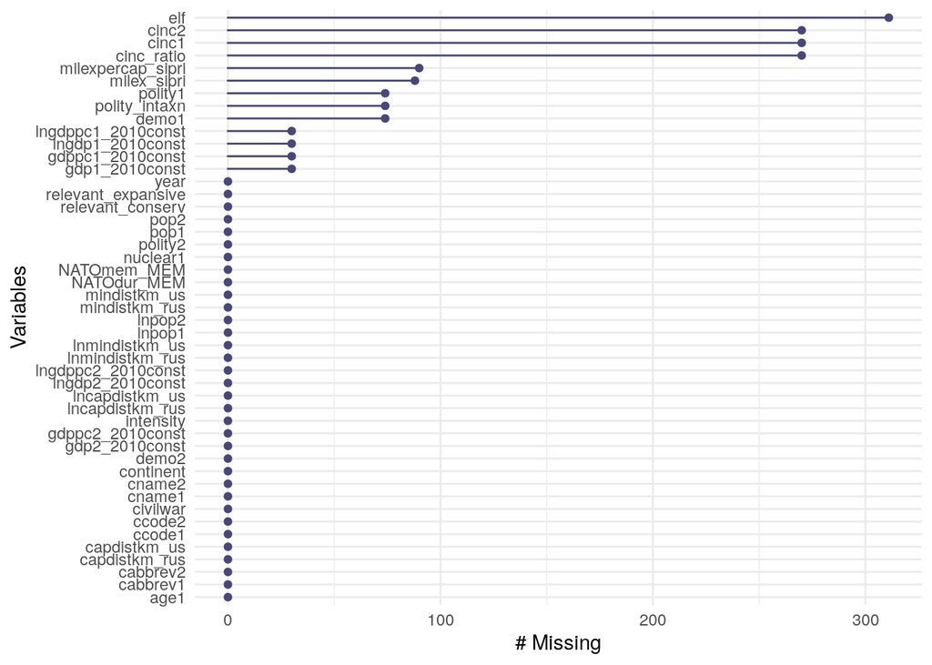

```r
# Reorder df
df <- df %>%
  dplyr::select(year,
                cname1, cabbrev1, ccode1,
                cname2, cabbrev2, ccode2,
                continent, relevant_expansive, relevant_conserv,
                intensity,
                capdistkm_us, mindistkm_us, capdistkm_rus, mindistkm_rus,
                lncapdistkm_us, lnmindistkm_us, lncapdistkm_rus, lnmindistkm_rus,
                NATOmem_MEM, NATOdur_MEM,
                cinc1, cinc2, cinc_ratio,
                milex_sipri, milexpercap_sipri,
                nuclear1,
                gdp1_2010const, lngdp1_2010const, gdp2_2010const, lngdp2_2010const,
                gdppc1_2010const, lngdppc1_2010const, gdppc2_2010const, lngdppc2_2010const,
                pop1, lnpop1, pop2, lnpop2,
                elf,
                age1,
                demo1, demo2, polity1, polity2, polity_intaxn,
                civilwar)

# Check missing
naniar::gg_miss_var(df)
```

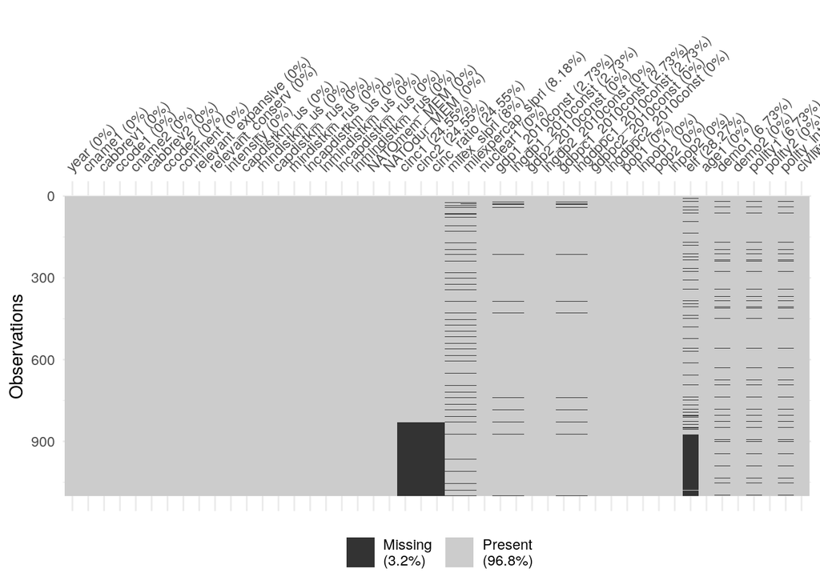

```r
visdat::vis_miss(df)
```

```r
df %>%
  dplyr::filter(is.na(gdp1_2010const)) %>%
  DT::datatable()
```

|  | year | cname1 | cabbrev1 | ccode1 | cname2 | cabbrev2 | ccode2 | continent | relevant_expansive | relevant_conserv | intensity | capdistkm_us | mindistkm_us | capdistkm_rus | mindistkm_rus | lncapdistkm_us | lnmindistkm_us | lncapdistkm_rus | lnmindistkm_rus | NATOmem_MEM | NATOdur_MEM | cinc1 | cinc2 | cinc_ratio | milex_sipri | milexpercap_sipri | nuclear1 | gdp1_2010const | lngdp1_2010const | … |
| --- | --- | --- | --- | --- | --- | --- | --- | --- | --- | --- | --- | --- | --- | --- | --- | --- | --- | --- | --- | --- | --- | --- | --- | --- | --- | --- | --- | --- | --- | --- |
| 1 | 1994 | Croatia | CRO | 344 | Russia | RUS | 365 | Europe | 0 | 0 | 0 | 7275 | 5969 | 1890 | 914 | 8.8923379140186 | 8.69450388142712 | 7.54486635685177 | 6.81893499417755 | 0 | -15 | 0.0011504 | 0.0670384 | 0.0168708057628232 | 2918 | 348.9 | 0 |  |  | … |
| 2 | 1994 | Yugoslavia | YUG | 345 | Russia | RUS | 365 | Europe | 1 | 1 | 0 | 7635 | 6285 | 1730 | 919 | 8.94063049443095 | 8.74608180819303 | 7.45646033216703 | 6.82438453954923 | 0 | 0 | 0.0025394 | 0.0670384 | 0.0364972735556456 |  |  | 0 |  |  | … |
| 3 | 1994 | Moldova | MLD | 359 | Russia | RUS | 365 | Europe | 1 | 1 | 0 | 7970 | 6606 | 1088 | 496 | 8.98356648897487 | 8.79588648557498 | 6.99302430562726 | 6.20861014661856 | 0 | 0 | 0.0005623 | 0.0670384 | 0.00831796120454374 | 30.5 |  | 0 |  |  | … |
| 4 | 1994 | Latvia | LAT | 367 | Russia | RUS | 365 | Europe | 1 | 0 | 0 | 7126 | 5643 | 854 | 0 | 8.8716470706158 | 8.63835008476419 | 6.7511131647748 | 0.00995033085316809 | 0 | -10 | 0.0003765 | 0.0670384 | 0.00558481878635139 | 107.3 | 13.3 | 0 |  |  | … |
| 5 | 1994 | Lithuania | LIT | 368 | Russia | RUS | 365 | Europe | 1 | 1 | 0 | 7320 | 5804 | 791 | 0 | 8.89850357557933 | 8.66647661678339 | 6.67457401799734 | 0.00995033085316809 | 0 | -10 | 0.000508 | 0.0670384 | 0.00752075610247178 | 90.2 | 5.8 | 0 |  |  | … |
| 6 | 1994 | Syria | SYR | 652 | Russia | RUS | 365 | Asia | 1 | 0 | 0 | 9470 | 7865 | 2451 | 606 | 9.15599083308026 | 8.97030622428512 | 7.80466337535121 | 6.40854526538838 | 0 | 0 | 0.0039824 | 0.0670384 | 0.0560737136162927 |  |  | 0 |  |  | … |
| 7 | 1995 | Syria | SYR | 652 | Russia | RUS | 365 | Asia | 1 | 0 | 0 | 9470 | 7865 | 2451 | 606 | 9.15599083308026 | 8.97030622428512 | 7.80466337535121 | 6.40854526538838 | 0 | 0 | 0.0039643 | 0.0629018 | 0.0592871425131718 |  |  | 0 |  |  | … |
| 8 | 1996 | Syria | SYR | 652 | Russia | RUS | 365 | Asia | 1 | 0 | 0 | 9470 | 7865 | 2451 | 606 | 9.15599083308026 | 8.97030622428512 | 7.80466337535121 | 6.40854526538838 | 0 | 0 | 0.0041413 | 0.0591888 | 0.065392285816697 |  |  | 0 |  |  | … |
| 9 | 1997 | Syria | SYR | 652 | Russia | RUS | 365 | Asia | 1 | 0 | 0 | 9470 | 7865 | 2451 | 606 | 9.15599083308026 | 8.97030622428512 | 7.80466337535121 | 6.40854526538838 | 0 | 0 | 0.0042635 | 0.0559937 | 0.0707550301042863 |  |  | 0 |  |  | … |
| 10 | 1998 | Syria | SYR | 652 | Russia | RUS | 365 | Asia | 1 | 0 | 0 | 9470 | 7865 | 2451 | 606 | 9.15599083308026 | 8.97030622428512 | 7.80466337535121 | 6.40854526538838 | 0 | 0 | 0.00412 | 0.0512986 | 0.0743432710317475 |  |  | 0 |  |  | … |

[output cut: 20 more lines]

```r
df %>%
  dplyr::filter(is.na(milex_sipri | milexpercap_sipri)) %>%
  dplyr::select(year, cname1, milex_sipri, milexpercap_sipri) %>%
  DT::datatable()
```

|  | year | cname1 | milex_sipri | milexpercap_sipri |
| --- | --- | --- | --- | --- |
| 1 | 1994 | North Macedonia |  |  |
| 2 | 1994 | Yugoslavia |  |  |
| 3 | 1994 | Bosnia &amp; Herzegovina |  |  |
| 4 | 1994 | Georgia |  |  |
| 5 | 1994 | Syria |  |  |
| 6 | 1994 | Saudi Arabia |  |  |
| 7 | 1995 | North Macedonia |  |  |
| 8 | 1995 | Yugoslavia |  |  |
| 9 | 1995 | Bosnia &amp; Herzegovina |  |  |
| 10 | 1995 | Georgia |  |  |

[output cut: 78 more lines]

# 6 Save data

Save the final version of the data that is now prepped for modeling

```r
saveRDS(df, paste0(here::here(), "/data/","grayzone_model.rds"))
write.csv(df, paste0(here::here(), "/data/","grayzone_model.csv"))
```

# 7 System info

This markdown file was last run and replicated on the following system

```r
Sys.info()
```

```
##                                               sysname
##                                               "Linux"
##                                               release
##                                    "5.4.0-56-generic"
##                                               version
## "#62~18.04.1-Ubuntu SMP Tue Nov 24 10:07:50 UTC 2020"
##                                              nodename
##                                             "fuegito"
##                                               machine
##                                              "x86_64"
##                                                 login
##                                        "andresgannon"
##                                                  user
##                                        "andresgannon"
##                                        effective_user
##                                        "andresgannon"
```